# Sensitivity Analysis

Source: [`vignettes/sensitivity-analysis.Rmd`](https://github.com/open-systems-pharmacology/ospsuite.reportingengine/blob/master/vignettes/sensitivity-analysis.Rmd)

# Overview

The sensitivity task aims at generating plots showing PK parameter sensitivity to variations of model input parameters. This vignette presents example workflows for setting up, evaluating and visualizing sensitivity analyses for both a mean model and a population.

## Inputs files required for sensitivity analysis

The only input file required for running a sensitivity analysis on a mean model is the `.pkml` simulation file. The path to this file (either the absolute path or the relative path with respect to the `workflowFolder` directory) is specified as a string:

```r
simulationFile <- system.file("extdata", "caffeine-simulation.pkml",
  package = "ospsuite.reportingengine"
)
```

For population sensitivity analyses, the user needs to similarly specify paths to `.csv` files containing data on the populations to be studied:

```r
populationFile1 <- system.file("extdata", "pop1.csv",
  package = "ospsuite.reportingengine"
)

populationFile2 <- system.file("extdata", "pop2.csv",
  package = "ospsuite.reportingengine"
)
```

Results obtained from the `calculateSensitivity` task are stored as csv files within the `SensitivityResults` subdirectory of the `workflowFolder` directory. These results are required in order to perform the `plotSensitivity` task, which generates plots of the sensitivity analysis results.

## Specification of quantities analyzed: model outputs and PK parameters

A sensitivity analysis will compute the variation in a scalar function of a time-series trajectory of a model output in response to variations in model variables. The model outputs are specified using paths to simulated quantities within the model. The scalar functions are PK parameter quantities such as `C_max` or `AUC`. Although the sensitivity analysis for a mean model or an individual within a population is evaluated for all PK parameters, the user has the option of specifying the subset of PK parameters for which sensitivity plots are to be generated. In addition, the user has the option to set custom display names for both the selected model outputs and PK parameters used in the sensitivity analysis.

Sets of output and PK parameter combinations for the sensitivity analysis are defined as follows:

```r
output1 <- Output$new(
  path = "Organism|Lung|Interstitial|Caffeine|Concentration", displayName = "op1",
  pkParameters = c(
    PkParameterInfo$new("C_max", "new_C_max"),
    PkParameterInfo$new("MRT", "new_MRT")
  )
)
```

and

```r
output2 <- Output$new(
  path = "Organism|ArterialBlood|Plasma|Caffeine|Concentration", displayName = "op2",
  pkParameters = c(
    PkParameterInfo$new("t_max", "new_t_max"),
    PkParameterInfo$new("AUC_tEnd", "new_AUC_tEnd")
  )
)
```

Here, `output1` and `output2` are `Output` objects. The `path` input to the constructors of these objects gives the path to the model output. For example, the `path` input for `output1` points to the concentration of caffeine in lung interstitial tissue, `Organism|Lung|Interstitial|Caffeine|Concentration`. This model output is given the display name `op1`. The PK parameters chosen for this example are the `C_max` and `MRT`, which are given the display names `new_C_max` and `new_MRT`, respectively. Similarly, `output2` points to the model output with path `Organism|ArterialBlood|Plasma|Caffeine|Concentration`. The PK parameters selected for `output2` are `t_max` and `AUC_tEnd`, for which the respective display names `new_t_max` and `new_AUC_tEnd` will be used.

### Mean model workflow

The mean model workflow operates on `SimulationSet` objects. These objects store the path to the model simulation (`.pkml`) file as well as the `Output` objects (described above). A descriptive name for the `SimulationSet` object can be provided using the `simulationSetName` field of the `SimulationSet` constructor. For the mean model workflow, a `SimulationSet` object is created as follows:

```r
ms <- SimulationSet$new(
  simulationSetName = "simulationSet1",
  simulationFile = simulationFile,
  outputs = c(output1, output2)
)
```

A mean model workflow object is then instantiated using the `SimulationSet` object `ms` as follows:

```r
mwf <- MeanModelWorkflow$new(
  simulationSets = ms,
  workflowFolder = "meanSensitivityExample"
)
```

In this mean model workflow, the tasks will consist of a sensitivity analysis followed by generation of plots of the sensitivity analysis results. These two tasks are activated as follows:

```r
mwf$simulate$activate()
mwf$calculateSensitivity$activate()
mwf$plotSensitivity$activate()
```

The model parameters to be perturbed in the sensitivity analysis are next set:

```r
mwf$calculateSensitivity$settings$variableParameterPaths <- c(
  "Organism|Heart|Volume",
  "Organism|Lung|Volume",
  "Organism|Kidney|Volume",
  "Organism|Brain|Volume",
  "Organism|Muscle|Volume",
  "Organism|LargeIntestine|Volume",
  "Organism|PortalVein|Volume",
  "Organism|Spleen|Volume",
  "Organism|Skin|Volume",
  "Organism|Pancreas|Volume",
  "Organism|SmallIntestine|Mucosa|UpperIleum|Fraction mucosa",
  "Organism|SmallIntestine|Volume",
  "Organism|Lumen|Effective surface area variability factor",
  "Organism|Bone|Volume",
  "Organism|Stomach|Volume"
)
```

The properties of the sensitivity plots to be generated are set next. The field `totalSensitivityThreshold` is used to filter out from the sensitivity plots any model variables that contribute little to the total sensitivity of the model. The `maximalParametersPerSensitivityPlot` field limits the number of model variables to be displayeed in sensitivity plots. The axis font size is set using the parameters `xAxisFontSize` and `yAxisFontSize`.

```r
mwf$plotSensitivity$settings <- SensitivityPlotSettings$new(
  totalSensitivityThreshold = 0.9,
  maximalParametersPerSensitivityPlot = 12,
  xAxisFontSize = 10,
  yAxisFontSize = 10
)
```

With the `calculateSensitivity` and `plotSensitivity` tasks now set up, the sensitivity evaluation and plot are started with the command `runWorkflow`:

```r
mwf$runWorkflow()
```

The output report, containing the mean model sensitivity plots from this example, is shown below.

# Table of Contents

- 1 Sensitivity Analysis
  - 1.1 Sensitivity Analysis for simulationSet1

# 1 Sensitivity Analysis

## 1.1 Sensitivity Analysis for simulationSet1

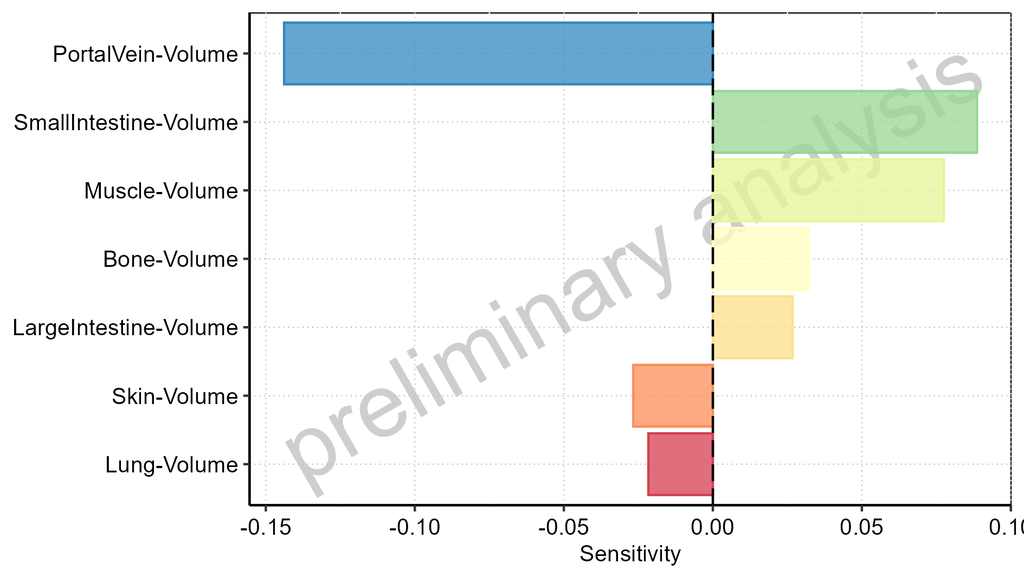

**Figure 1-1: Most sensitive parameters for new_C_max of op1.**

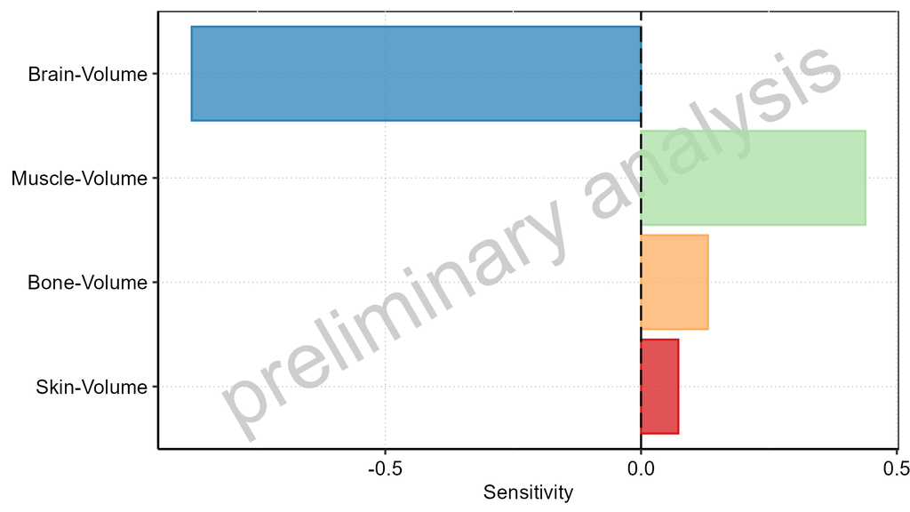

**Figure 1-2: Most sensitive parameters for new_MRT of op1.**

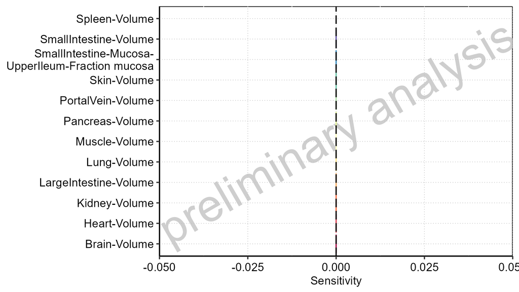

**Figure 1-3: Most sensitive parameters for new_t_max of op2.**

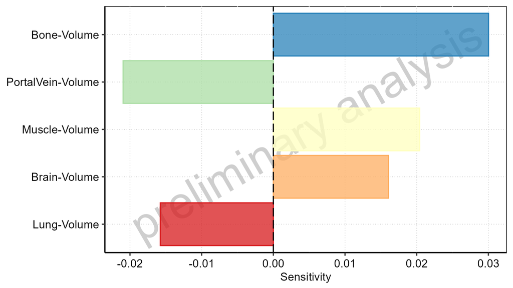

**Figure 1-4: Most sensitive parameters for new_AUC_tEnd of op2.**

### Population model workflow

Unlike the mean model sensitivity analysis, a population sensitivity analysis depends on the outcomes of the `calculatePKParameters` task for the population. This task, in turn, turn depends on the results of the `simulate` task for the population. The population sensitivity analysis proceeds as follows:

- Step 1) The model is simulated for the entire population using the `simulate` task.
- Step 2) Using the `calculatePKParameters` task, the PK parameters of each user-specified model output are calculated for each individual in the population based on their simulation results (evaluated in Step 1). For each PK parameter, the computations in Step 2 result in a distribution of that parameter over the entire population.
- Step 3) The population sensitivity analysis of a PK parameter of a model output is composed of sensitivity analyses, similar to the mean model sensitivity analysis, conducted for a selection of individuals within the population. The individuals chosen for the sensitivity analysis are those with PK parameters values that lie closest to user-specified quantiles of the pk parameter distributions computed in Step 2.

In this example, the sensitivity analysis will be conducted for two populations in parallel. In the first step, the model outputs to be analyzed are defined:

```r
populationOutputs <- c(output1,output2)
```

Next, `PopulationSimulationSet` objects are defined for each of the two populations:

```r
ps1 <- PopulationSimulationSet$new(
  simulationSetName = "popSimulationSet1",
  simulationFile = simulationFile,
  populationFile = populationFile1,
  outputs = populationOutputs
)

ps2 <- PopulationSimulationSet$new(
  simulationSetName = "popSimulationSet2",
  simulationFile = simulationFile,
  populationFile = populationFile2,
  outputs = populationOutputs
)
```

With this setup, the sensitivity of PK parameters of `output1` and `output2` will be analyzed for the two populations. The two `PopulationSimulationSet` objects are then used to create a `PopulationWorkflow`, the results of which are to be placed in the root directory `./popSensitivityExample`:

```r
pwf <- PopulationWorkflow$new(simulationSets = list(ps1,ps2),
                              workflowFolder = "popSensitivityExample",
                              workflowType = PopulationWorkflowTypes$parallelComparison)
```

Next, the required tasks of the workflow are activated. The sensitivity analysis and sensitivity plot tasks are activated using the commands

```r
pwf$calculateSensitivity$activate()
pwf$plotSensitivity$activate()
```

The population sensitivity analysis depends on the PK parameter calculations for the population, which in turn depend on population simulation results. If these pre-requisite tasks (`simulate` and `calculatePKParameters`) have not previously been run, they must also be activated:

```r
pwf$simulate$activate()
pwf$calculatePKParameters$activate()
```

The variables to be perturbed in the sensitivity analysis are specified as follows:

```r
pwf$calculateSensitivity$settings$variableParameterPaths <- c(
  "Organism|Heart|Volume",
  "Organism|Lung|Volume",
  "Organism|Kidney|Volume",
  "Organism|Brain|Volume",
  "Organism|Muscle|Volume",
  "Organism|LargeIntestine|Volume",
  "Organism|PortalVein|Volume",
  "Organism|Spleen|Volume",
  "Organism|Skin|Volume",
  "Organism|Pancreas|Volume",
  "Organism|SmallIntestine|Mucosa|UpperIleum|Fraction mucosa",
  "Organism|SmallIntestine|Volume",
  "Organism|Lumen|Effective surface area variability factor",
  "Organism|Bone|Volume",
  "Organism|Stomach|Volume"
)
```

The individuals within the population for which sensitivity will be evaluated are those with PK parameter values (as evaluated in the `calculatePKParameters` task) that lie closes to user-specified quantiles of the population’s PK parameter distributions. These quantiles are specified as follows:

```r
pwf$calculateSensitivity$settings$quantileVec <- c(0.25, 0.5, 0.75)
```

As with the mean model sensitivity plot, the population sensitivity plot is configured using an instance of a `SensitivityPlotSettings` object:

```r
pwf$plotSensitivity$settings <- SensitivityPlotSettings$new(totalSensitivityThreshold = 0.9,
                                                            maximalParametersPerSensitivityPlot = 12,
                                                            xAxisFontSize = 10,
                                                            yAxisFontSize = 10)
```

The population sensitivity workflow is run using the command:

```r
pwf$runWorkflow()
```

The results of the population sensitivity analysis are found in multiple `.csv` files within the `SensitivityResults` sub-directory of the workflow folder, as shown in the following figure:

[figure not shown]

Two sets of files make up the population sensitivity analysis results for this example, each corresponding to one of the `PopulationSimulationSet` objects (named `popSimulationSet1` and `popSimulationSet2`). For each set, there is one index file. The name of the index file is prefixed with the name of the `PopulationSimulationSet` object and carries the suffix `-popSensitivityResultsIndex.csv`). The index file `popSimulationSet1-popSensitivityResultsIndex.csv` contains the names of the individual sensitivity analysis results files (found within the `SensitivityResults` sub-directory of the workflow folder) obtained for the `PopulationSimulationSet` object `popSimulationSet1`. Its contents are shown in the following figure:

[figure not shown]

Two output paths are shown corresponding to `output1` (pink), `output2` (blue). Note that, as per the definitions of `output1` and `output2`, the only PK parameters analyzed for those two outputs are `C_max` and `MRT` for `output1` and `t_max` and `AUC_tEnd` for `output2`. For each model output and PK parameter combination, there are sensitivity analysis result files for three individuals given under the `Filename` column, each corresponding to one of the quantiles specified using `pwf$calculateSensitivity$settings$quantileVec`.

The output report, containing the population sensitivity plots from this example, is shown below.

# Table of Contents

- 1 Sensitivity Analysis

# 1 Sensitivity Analysis

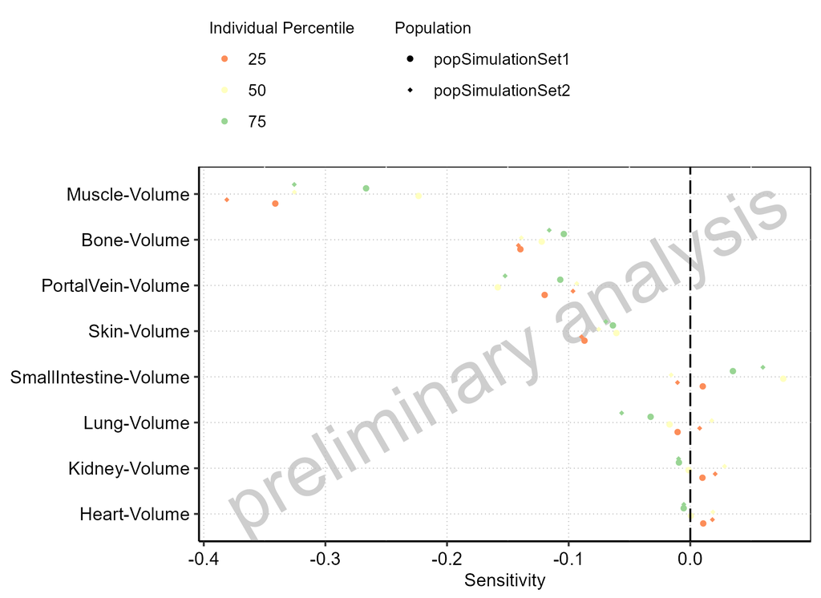

**Figure 1-1: Most sensitive parameters for new_C_max of op1 for individuals at percentiles 25, 50, 75 for popSimulationSet2, popSimulationSet1.**

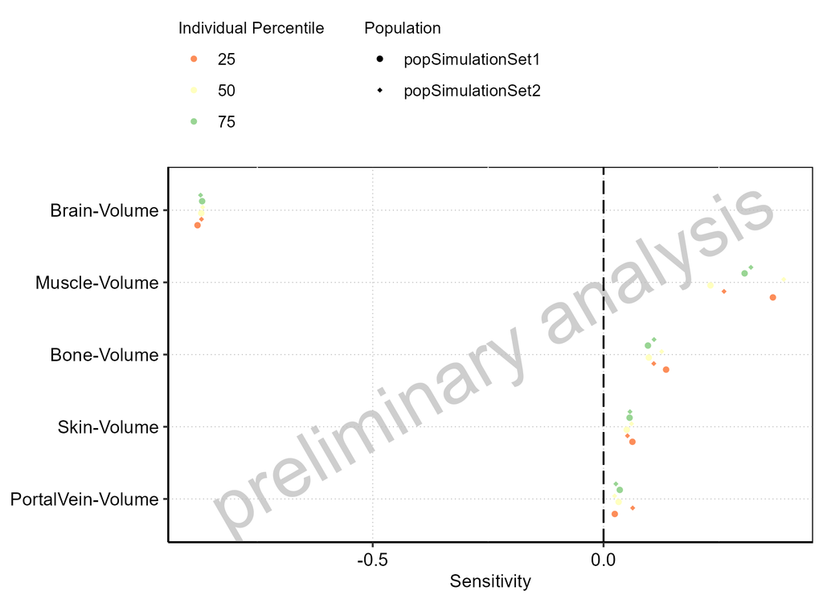

**Figure 1-2: Most sensitive parameters for new_MRT of op1 for individuals at percentiles 25, 50, 75 for popSimulationSet1, popSimulationSet2.**

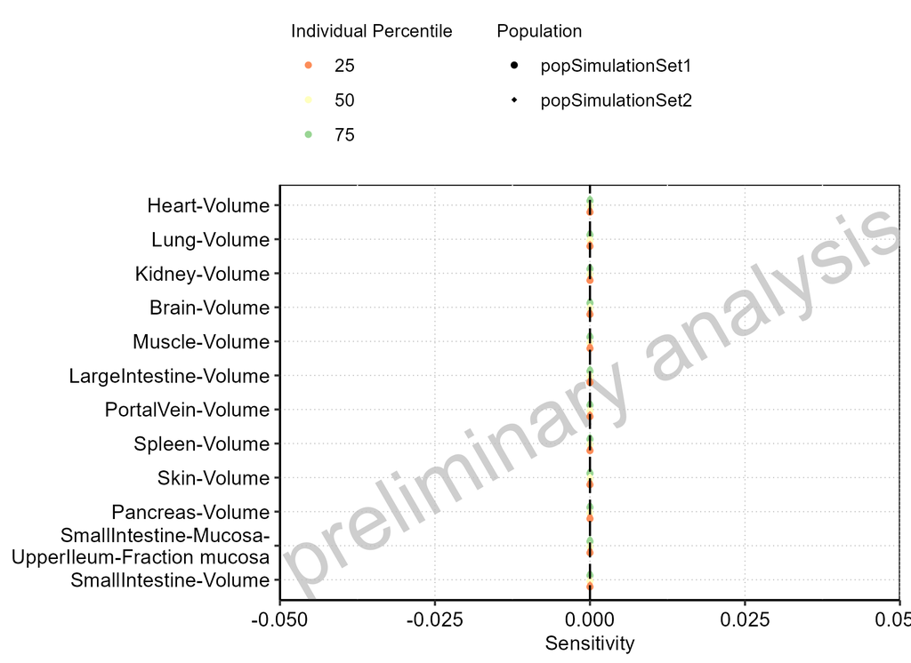

**Figure 1-3: Most sensitive parameters for new_t_max of op2 for individuals at percentiles 25, 50, 75 for popSimulationSet1, popSimulationSet2.**

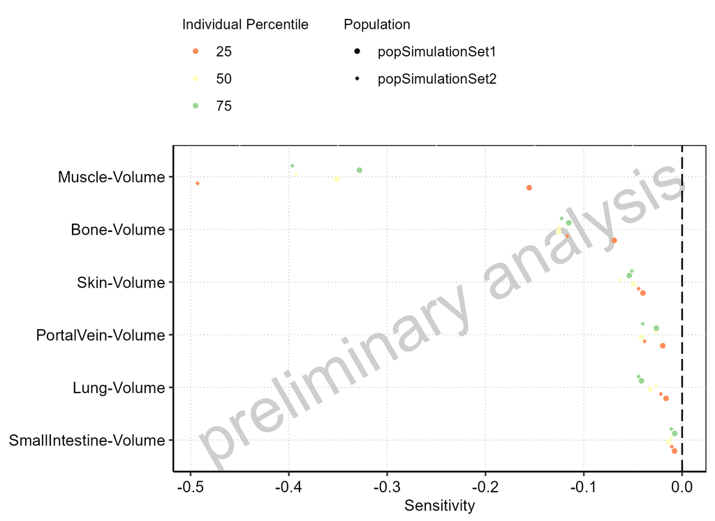

**Figure 1-4: Most sensitive parameters for new_AUC_tEnd of op2 for individuals at percentiles 25, 50, 75 for popSimulationSet2, popSimulationSet1.**